# Strategy

Zachary Johnson - Student ID 12375220

Adding imports/preliminaries

```python
import os
import warnings
from functools import reduce
from datetime import datetime, timedelta
import matplotlib.dates as mdates
import random
import math
import datetime
import quandl
import shutil  # Import shutil for file copying
import matplotlib.pyplot as plt
import pandas as pd
from pandas.tseries.offsets import BDay
import numpy as np
import scipy as sp
import plotnine as p9
import quandl
import seaborn as sns
import requests
import zipfile
import io
%matplotlib inline
```

```python
def grab_quandl_table(table_path, avoid_download=False, **kwargs):
    root_data_dir = os.path.join(os.environ['USERPROFILE'], "quandl_data_table_downloads")
    my_date = datetime.datetime.now().strftime("%Y%m%d")
    data_file = os.path.join(root_data_dir, f"{table_path}_{my_date}.zip")
    data_file = data_file.replace('/', os.sep)

    # Check if file exists and avoid_download is True
    if avoid_download and os.path.exists(data_file):
        print(f"File already exists, skipping download: {data_file}")
        return data_file

    # Ensure directory exists
    table_dir = os.path.dirname(data_file)
    if not os.path.isdir(table_dir):
        print(f'Creating new data dir {table_dir}')
        os.mkdir(table_dir)

    # Download the file
    print(f"Downloading file to: {data_file}")
    quandl.export_table(table_path, filename=data_file, api_key="wrH8c1Apa74XuRWvFNwi", **kwargs)

    # Check if the download was successful
    if os.path.exists(data_file) and os.stat(data_file).st_size > 0:
        print(f"Download successful: {data_file}")
    else:
        print(f"Data file {data_file} failed download")
        return

    return data_file

def fetch_quandl_table(table_path, avoid_download=True, **kwargs):
    return pd.read_csv(grab_quandl_table(table_path, avoid_download=avoid_download, **kwargs))
```

# Strategy: Carry Trade

We will implement a cross currency swap carry strategy. We will start each week with $10mm USD (4/5 borrowed and 1/5 our own capital), we will then conver this amount to pounds (we will pay borrowing costs on the 4/5 pounds we are borrowing). GBP will then be our funding currency, we will then use this capital position to buy 10mm USD of the currency in question (the lending currency). After this we will hold for a week and collect the higher yield (determined by bond pricing and zero curves). Once the week is done we will convert back to pounds, deliver what was borrowed plus interest. What is left is the converted back to USD and is considered our PNL. We will do this with the information below and pandas.

IUDSOIA BOE Data import and format

```python
iudsoia = pd.DataFrame()

url_endpoint = 'http://www.bankofengland.co.uk/boeapps/iadb/fromshowcolumns.asp?csv.x=yes'

payload = {
    'Datefrom'   : '01/Jan/2000',
    'Dateto'     : '17/Feb/2024',
    'SeriesCodes': 'IUDSOIA',
    'CSVF'       : 'TN',
    'UsingCodes' : 'Y',
    'VPD'        : 'Y',
    'VFD'        : 'N'
}

headers = {
    'User-Agent': 'Mozilla/5.0 (X11; Linux x86_64) '
                  'AppleWebKit/537.36 (KHTML, like Gecko) '
                  'Chrome/54.0.2840.90 '
                  'Safari/537.36'
}

response = requests.get(url_endpoint, params=payload, headers=headers)
if response.status_code == 200:
    iudsoia = pd.read_csv(io.BytesIO(response.content))
    iudsoia.rename(columns={'DATE': 'date'}, inplace=True)
    iudsoia.rename(columns={'IUDSOIA': 'OIS'}, inplace=True)

iudsoia['OIS'] = iudsoia['OIS'] / 100

iudsnzc = pd.DataFrame()

url_endpoint = 'http://www.bankofengland.co.uk/boeapps/iadb/fromshowcolumns.asp?csv.x=yes'

payload = {
    'Datefrom'   : '01/Jan/2000',
    'Dateto'     : '17/Feb/2024',
    'SeriesCodes': 'IUDSNZC',
    'CSVF'       : 'TN',
    'UsingCodes' : 'Y',
    'VPD'        : 'Y',
    'VFD'        : 'N'
}

headers = {
    'User-Agent': 'Mozilla/5.0 (X11; Linux x86_64) '
                  'AppleWebKit/537.36 (KHTML, like Gecko) '
                  'Chrome/54.0.2840.90 '
                  'Safari/537.36'
}

response = requests.get(url_endpoint, params=payload, headers=headers)
if response.status_code == 200:
    iudsnzc = pd.read_csv(io.BytesIO(response.content))
    iudsnzc.rename(columns={'DATE': 'date'}, inplace=True)
    iudsnzc.rename(columns={'IUDSNZC': '5Y_GBP'}, inplace=True)

iudsnzc['5Y_GBP'] = iudsnzc['5Y_GBP'] / 100
```

Swap Rate Data Import and format

```python
file_path = 'C:/Users/zacjo/Downloads/InferredYieldCurves_2024.tab'
swap_rates = pd.read_csv(file_path, sep='\t')
swap_rates = swap_rates[(swap_rates['shortname'] == 'Romania') | (swap_rates['shortname'] == 'Hungary') | (swap_rates['shortname'] == 'Arab Rep Egypt') | (swap_rates['shortname'] == 'Rep Costa Rica')]
swap_rates.rename(columns={'shortname': 'code'}, inplace=True)
```

QUANDL Currency Data import

```python
fx = fetch_quandl_table('EDI/CUR', code=['GBP', 'EGP', 'HUF', 'CRC', 'RON'], avoid_download=True)
```

```
File already exists, skipping download: C:\Users\zacjo\quandl_data_table_downloads\EDI\CUR_20240219.zip
```

Formatting dates

```python
iudsoia['date'] = pd.to_datetime(iudsoia['date'], format='%d %b %Y')
iudsnzc['date'] = pd.to_datetime(iudsnzc['date'], format='%d %b %Y')
swap_rates['date'] = pd.to_datetime(swap_rates['date'])
fx['date'] = pd.to_datetime(fx['date'])
max_dates = [fx['date'].max(), swap_rates['date'].max(), iudsoia['date'].max(), iudsnzc['date'].max()]
min_dates = [fx['date'].min(), swap_rates['date'].min(), iudsoia['date'].min(), iudsnzc['date'].min()]
min_date = max(min_dates)
max_date = min(max_dates)

iudsoia = iudsoia[(iudsoia['date'] >= min_date) & (iudsoia['date'] <= max_date)]
iudsnzc = iudsnzc[(iudsnzc['date'] >= min_date) & (iudsnzc['date'] <= max_date)]
swap_rates = swap_rates[(swap_rates['date'] >= min_date) & (swap_rates['date'] <= max_date)]
fx = fx[(fx['date'] >= min_date) & (fx['date'] <= max_date)]
fx['code'] = fx['code'].astype(str)
```

Formatting swap rate data and adding zero curves

```python
def convert_shortname_to_code(shortname):
    if shortname == 'Romania':
        return 'RON'
    elif shortname == 'Hungary':
        return 'HUF'
    elif shortname == 'Arab Rep Egypt':
        return 'EGP'
    elif shortname == 'Rep Costa Rica':
        return 'CRC'
    else:
        return 'nan'

swap_rates['code'] = swap_rates['code'].apply(convert_shortname_to_code)

def convert_tenor_to_years(tenor):
    if tenor.endswith('M'):
        return int(tenor.rstrip('M')) / 12
    elif tenor.endswith('Y'):
        return float(tenor.rstrip('Y'))
    else:
        return float('nan')

swap_rates['tenor_years'] = swap_rates['tenor'].apply(convert_tenor_to_years)
swap_rates['tenor_years'] = swap_rates['tenor_years'].astype(float)
swap_curves = swap_rates.pivot_table(index=['code', 'date'], columns='tenor_years', values='yield', aggfunc='first').reset_index()
##dropping rows where either 1Y or 5Y spot rates are nan
rows_to_drop = swap_curves[(swap_curves[1.0].isna()) | (swap_curves[5.0].isna())].index
swap_curves.drop(index=rows_to_drop, inplace=True)

def compute_zcb_curve_row(spot_rates_row):
    tenors = np.array([0.5, 1.0, 5.0, 10.0])
    zcb_rates = {}

    calculated_zcb = []

    for tenor in tenors:
        spot_rate = spot_rates_row.get(tenor)
        if pd.isna(spot_rate):
            zcb_rates[f"{tenor}Z"] = np.nan
            continue

        if not calculated_zcb:
            zcb_rate = spot_rate
        else:
            times = np.arange(tenor - 0.5, 0, step=-0.5)[::-1]
            coupon_half_yr = 0.5 * spot_rate
            if times.size > 0:
                interp_tenors = np.array([t for t in calculated_zcb])
                interp_zcb_rates = np.array([zcb_rates[f"{t}Z"] for t in calculated_zcb])
                z = np.interp(times, interp_tenors, interp_zcb_rates)
                preceding_coupons_val = (coupon_half_yr * np.exp(-z * times)).sum()
                zcb_rate = -np.log((1 - preceding_coupons_val) / (1 + coupon_half_yr)) / tenor
            else:
                zcb_rate = spot_rate

        zcb_rates[f"{tenor}Z"] = zcb_rate
        calculated_zcb.append(tenor)

    return pd.Series(zcb_rates)

zcb_columns = swap_curves.apply(compute_zcb_curve_row, axis=1)
swap_curves = pd.concat([swap_curves, zcb_columns], axis=1)
swap_curves['code'] = swap_curves['code'].astype(str)
```

Combining data based on dates and codes to vectorize trading strategy

```python
curves_fx = pd.merge(swap_curves, fx, on=['code', 'date'], how='inner')
fx_gbp = fx[fx['code'] == 'GBP'].copy()
fx_gbp = fx_gbp[['date', 'rate']]
fx_gbp.rename(columns={'rate': 'GBP'}, inplace=True)
curves_fx_gbp = pd.merge(curves_fx,fx_gbp, on=['date'], how='inner')
curves_fx_ois = pd.merge(curves_fx_gbp, iudsoia, on=['date'], how='inner')
all_data = pd.merge(curves_fx_ois, iudsnzc, on=['date'], how='inner')
all_data = all_data.groupby('code', group_keys=False).apply(lambda x: x.sort_values('date'))
```

Adding shifted dates and columns to look at what happened one week ago at each date (for vectorization)

```python
all_data['shifted_date'] = all_data.groupby('code')['date'].transform(lambda x: x - BDay(5))
temp_df = all_data.set_index(['code', 'date'])
all_data = all_data.merge(temp_df[[5.0, '0.5Z', '1.0Z', '5.0Z', '10.0Z', 'rate','GBP', 'OIS', '5Y_GBP']], how='left', left_on=['code', 'shifted_date'], right_index=True, suffixes=('', '_shifted'))
columns_to_fill = ['5.0_shifted', '0.5Z_shifted', '1.0Z_shifted', '5.0Z_shifted', '10.0Z_shifted', 'rate_shifted','GBP_shifted', 'OIS_shifted', '5Y_GBP_shifted']
for col in columns_to_fill:
    all_data[col] = all_data.groupby('code')[col].ffill()

rows_to_drop = all_data[(all_data['5.0_shifted'].isna()) | (all_data['0.5Z_shifted'].isna()) | (all_data['1.0Z_shifted'].isna()) | (all_data['5.0Z_shifted'].isna()) | (all_data['10.0Z_shifted'].isna()) | (all_data['rate_shifted'].isna()) | (all_data['GBP_shifted'].isna()) | (all_data['OIS_shifted'].isna()) | (all_data['5Y_GBP_shifted'].isna())].index
all_data.drop(index=rows_to_drop, inplace=True)
```

Calculating bond prices both at the current date and shifted date based on current values and shifted values.

```python
def bond_price_0w(row):
    tenors = np.array([0.5, 1.0, 5.0, 10.0], dtype=float)
    zcb_columns = ['0.5Z_shifted', '1.0Z_shifted', '5.0Z_shifted', '10.0Z_shifted']

    zcb_rates = row[zcb_columns].values
    zcb = pd.DataFrame(zcb_rates, index=tenors, columns=['ZCB_Rate'])
    zcb.dropna(inplace=True)

    zcb['ZCB_Rate'] = pd.to_numeric(zcb['ZCB_Rate'], errors='coerce')

    coupon_rate = row['5.0_shifted']
    tenor = 5.0
    times = np.arange(tenor, 0, step=-0.5)[::-1]
    if times.shape[0]==0:
        p = 1.0
    else:
        r = np.interp(times, zcb.index.values, zcb['ZCB_Rate'].values)
        p = np.exp(-tenor*r[-1]) + 0.5 * coupon_rate * np.exp(-r*times).sum()
    return p

def bond_price_1w(row):
    tenors = np.array([0.5, 1.0, 5.0, 10.0], dtype=float)
    zcb_columns = ['0.5Z', '1.0Z', '5.0Z', '10.0Z']

    zcb_rates = row[zcb_columns].values
    zcb = pd.DataFrame(zcb_rates, index=tenors, columns=['ZCB_Rate'])
    zcb.dropna(inplace=True)

    zcb['ZCB_Rate'] = pd.to_numeric(zcb['ZCB_Rate'], errors='coerce')

    coupon_rate = row['5.0_shifted']
    tenor = 5 - (1/52)
    times = np.arange(tenor, 0, step=-0.5)[::-1]
    if times.shape[0]==0:
        p = 1.0
    else:
        r = np.interp(times, zcb.index.values, zcb['ZCB_Rate'].values)
        p = np.exp(-tenor*r[-1]) + 0.5 * coupon_rate * np.exp(-r*times).sum()
    return p

all_data['bond_price_0w'] = all_data.apply(bond_price_0w, axis=1)
all_data['bond_price_1w'] = all_data.apply(bond_price_1w, axis=1)
```

Implementing cross currency positions and trades.

```python
all_data['opening_pos_usd'] = 10000000
condition = (all_data['5.0_shifted'] < (all_data['5Y_GBP_shifted'] + 0.005))
all_data.loc[condition, 'opening_pos_usd'] = 0
all_data['opening_pos_gbp'] = all_data['opening_pos_usd'] * all_data['GBP_shifted']
all_data['opening_pos_curr'] = all_data['opening_pos_usd'] * all_data['rate_shifted']
all_data['bond_diff'] = all_data['bond_price_1w'] - all_data['bond_price_0w']
all_data['xccy'] = all_data['bond_diff'] * all_data['opening_pos_curr']
all_data['ending_pos_curr'] = all_data['xccy'] + all_data['opening_pos_curr']
all_data['ending_pos_usd'] = all_data['ending_pos_curr'] / all_data['rate']
all_data['ending_pos_gbp'] = all_data['ending_pos_usd'] * all_data['GBP']
all_data['gbp_diff'] = all_data['ending_pos_gbp'] - all_data['opening_pos_gbp']
all_data['xccy_pnl_usd'] = all_data['gbp_diff'] / all_data['GBP']
##1.4 is to account for weekends in borrowing costs.
all_data['borrow_costs'] = ((4/5) * all_data['opening_pos_gbp'] * all_data['OIS'] * (1.4/360)) / all_data['GBP']
```

```python
all_data.sort_values(['code', 'date'], inplace=True)
```

Function to only include weekly data.

```python
def find_closest_dates(group):
    start_date = group['date'].iloc[0]
    max_date = group['date'].iloc[-1]
    selected_dates = [start_date]
    current_date = start_date
    while True:
        target_date = current_date + BDay(5)
        if target_date > max_date:
            break

        closest_date = group[group['date'] >= target_date]['date'].min()
        if pd.isnull(closest_date):
            break

        selected_dates.append(closest_date)
        current_date = closest_date

    return group[group['date'].isin(selected_dates)]

all_data_dates = all_data.groupby('code', group_keys=False).apply(find_closest_dates)
```

Calculating the cumulative sum of borrowing costs over the week.

```python
def calculate_cumulative_sum(group, all_data):
    results = []
    for date in group['date']:
        start_date = date - BDay(5)
        sum_borrow_costs = all_data[(all_data['code'] == group['code'].iloc[0]) & (all_data['date'] > start_date) & (all_data['date'] <= date)]['borrow_costs'].sum()
        results.append({'date': date, 'code': group['code'].iloc[0], 'borrow_costs_sum': sum_borrow_costs})
    return pd.DataFrame(results)

def wrapper_apply_cumsum(filtered_dates, all_data):
    cumsum_results = []
    for _, group in filtered_dates.groupby('code'):
        cumsum_results.append(calculate_cumulative_sum(group, all_data))
    # Concatenate all result DataFrames
    return pd.concat(cumsum_results)


all_data_cost = wrapper_apply_cumsum(all_data_dates, all_data)
all_data_dates.reset_index(inplace=True, drop=True)
data = pd.merge(all_data_dates, all_data_cost, on=['code', 'date'], how='left')
```

Calculating cumulative weekly pnl.

```python
data['weekly_pnl_usd'] = data['xccy_pnl_usd'] - data['borrow_costs_sum']
data['cumulative_pnl'] = data.groupby('code')['weekly_pnl_usd'].cumsum()
data['5Y_spread'] = data['5.0_shifted'] - data['5Y_GBP_shifted']
```

Plotting functions.

```python
def plot_gbp_and_code_rate(df, code):
    fig, ax1 = plt.subplots(figsize=(14, 7))

    gbp_data = df[df['code'] == 'CRC']
    ax1.scatter(gbp_data['date'], gbp_data['GBP'], s=10, color='blue', label='GBP')
    ax1.set_xlabel('Date')
    ax1.set_ylabel('GBP Rate', color='blue')
    ax1.tick_params(axis='y', labelcolor='blue')

    ax2 = ax1.twinx()
    rate_data = df[df['code'] == code]
    ax2.scatter(rate_data['date'], rate_data['rate'], s=10, color='red', label=f'Rate {code}')
    ax2.set_ylabel(f'{code} Rate', color='red')
    ax2.tick_params(axis='y', labelcolor='red')

    # Title and legend
    fig.suptitle(f'GBP and {code} Rate Over Time')
    ax1.legend(loc='upper left')
    ax2.legend(loc='upper right')

    plt.show()

def plot_gbps_and_code_s(df, code):
    fig, ax1 = plt.subplots(figsize=(14, 7))

    # Plot GBP 5Y Swap Rate using 'CRC' as the representative code
    gbp_data = df[df['code'] == 'CRC']
    ax1.scatter(gbp_data['date'], gbp_data['5Y_GBP'], s=10, color='blue', label='5Y Swap Rate GBP')

    # Plot the 5Y Swap Rate for the provided currency code
    rate_data = df[df['code'] == code]
    ax1.scatter(rate_data['date'], rate_data['5.0'], s=10, color='red', label=f'5Y Swap Rate {code}')

    ax1.set_xlabel('Date')
    ax1.set_ylabel('Swap Rate')
    ax1.legend(loc='best')
    ax1.set_title(f'5Y GBP and {code} Swap Rates Over Time')

    plt.show()

def plot_cumulative_pnl(df):
    plt.figure(figsize=(14, 7))

    for code in df['code'].unique():
        subset = df[df['code'] == code]
        plt.scatter(subset['date'], subset['cumulative_pnl'], s=10, label=f'PnL {code}')

    plt.xlabel('Date')
    plt.ylabel('Cumulative PnL')
    plt.title('Cumulative PnL Over Time by Code')
    plt.legend()
    plt.show()

def plot_5Y(df):
    plt.figure(figsize=(14, 7))

    for code in df['code'].unique():
        subset = df[df['code'] == code]
        plt.scatter(subset['date'], subset['5Y_spread'], s=10, label=f'5Y Spread {code}')

    plt.xlabel('Date')
    plt.ylabel('5Y Spreads')
    plt.title('5Y Spreads over Time')
    plt.legend()
    plt.show()

def plot_correlation_matrices(df):
    codes = df['code'].unique()

    for code in codes:
        fig, ax = plt.subplots(figsize=(10, 8))
        subset = df[df['code'] == code]
        corr_matrix = subset[['rate', 'cumulative_pnl', '5.0', '5Y_GBP', 'GBP', '5Y_spread']].corr()

        sns.heatmap(corr_matrix, annot=True, cmap='coolwarm', ax=ax)
        plt.title(f'Correlation Matrix for {code}')
        plt.show()

def plot_rate_correlations(df):
    rate_pivot = df.pivot(index='date', columns='code', values='rate')

    rate_corr_matrix = rate_pivot.corr()

    fig, ax = plt.subplots(figsize=(10, 8))
    sns.heatmap(rate_corr_matrix, annot=True, cmap='coolwarm', ax=ax)
    plt.title('Rate Correlations Between Currencies')
    plt.show()

def plot_pnl_correlations(df):
    rate_pivot = df.pivot(index='date', columns='code', values='cumulative_pnl')

    rate_corr_matrix = rate_pivot.corr()

    fig, ax = plt.subplots(figsize=(10, 8))
    sns.heatmap(rate_corr_matrix, annot=True, cmap='coolwarm', ax=ax)
    plt.title('PNL Correlations Between Currencies')
    plt.show()

def plot_5y_correlations(df):
    rate_pivot = df.pivot(index='date', columns='code', values='5.0')

    rate_corr_matrix = rate_pivot.corr()

    fig, ax = plt.subplots(figsize=(10, 8))
    sns.heatmap(rate_corr_matrix, annot=True, cmap='coolwarm', ax=ax)
    plt.title('5Y Swap Rate Correlations Between Currencies')
    plt.show()
```

# Analysis

We now have data for each individual strategy. Below is our cumulative PNL over time for each strategy.

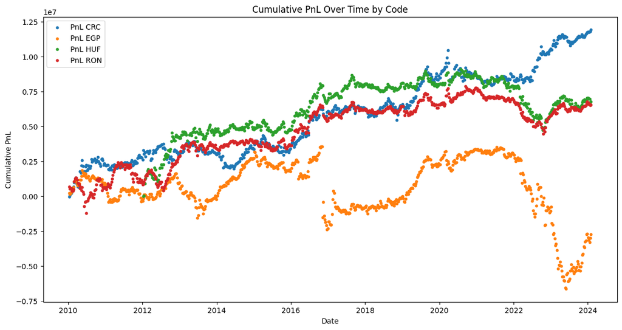

```python
plot_cumulative_pnl(data)
```

As we can see from the above, the strategies all performed well, with each making money besides EGP. This indicates that the cross currency carry strategy is a profitable one, as long as exchange and swap rates are in your favor. However as we can see from the above, you can also lose money, in some cases quickly. We will no analyse why the different strategies performed in the way that they did. First we will look at the different 5Y Spreads throughout each strategy.

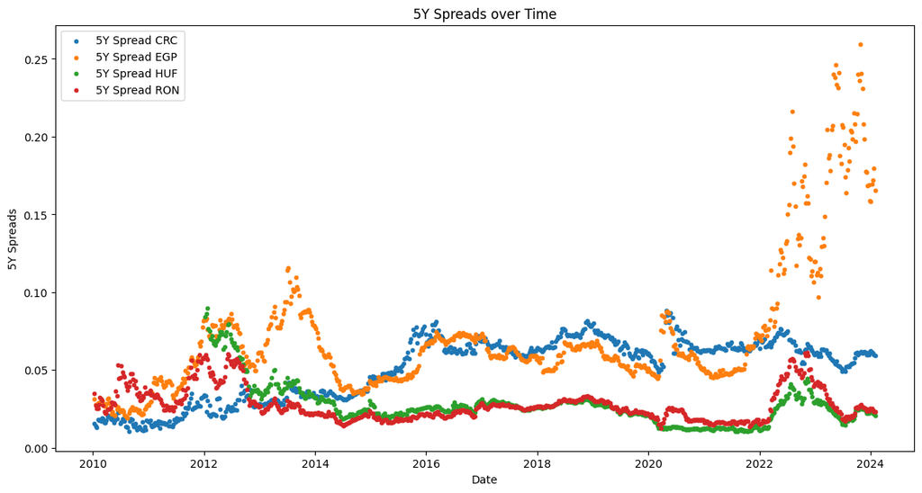

```python
plot_5Y(data)
```

Based on the above we can see that CRC and EGP had the best spreads as compared to GBP over time. And, given the outsized spread EGP had over GBP for quite a long duration, one would expect this strategy to be profitable. However, as seen in our PNL data above, it was not. All of the others were profitable, indicating that while spread is important one must also look at other risk factors like FX risk. We will analyze each pair in more detail below.

### EGP

EGP was the only currency that lost money in our strategy so we will analyze it first. We will first take a look at the EGP rate over time as compared to GBP.

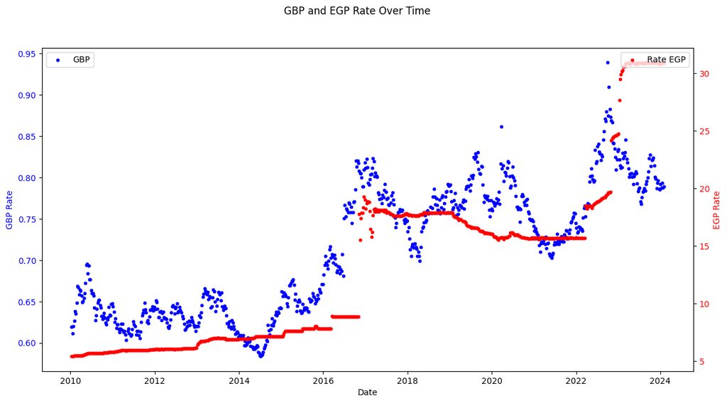

```python
plot_gbp_and_code_rate(data, 'EGP')
```

The above shows that while GBP vs USD moved in a relatively tight band (especially YoY), EGP vs USD moved erratically and looks to have been devalued various times. It is also of note that these devaluations seem to correlate exactly to the losses we took with this strategy in 2017 and then again in 2023. The losses were sudden and steep, as are the currency moves, indicating a devaluation and not typical moves vs. the dollar. We will now take a look at swap rates in the same time frame.

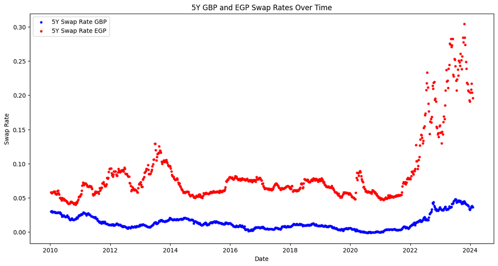

```python
plot_gbps_and_code_s(data, 'EGP')
```

### CRC

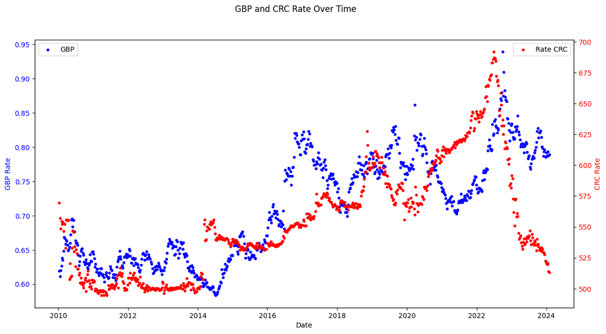

```python
plot_gbp_and_code_rate(data, 'CRC')
```

As we can see from the above, CRC moved around substantially, and while it looks as though there was a slight devaluation in 2014, it appears to have been stable otherwise. By stable I really mean moving predictably over time and without large jumps. We can see that it lost strength against the dollar especially throughout 2022-2023, however it came back and settled in its normal range. Due to these characteristics it would seem to be a good candidate for our strategy.

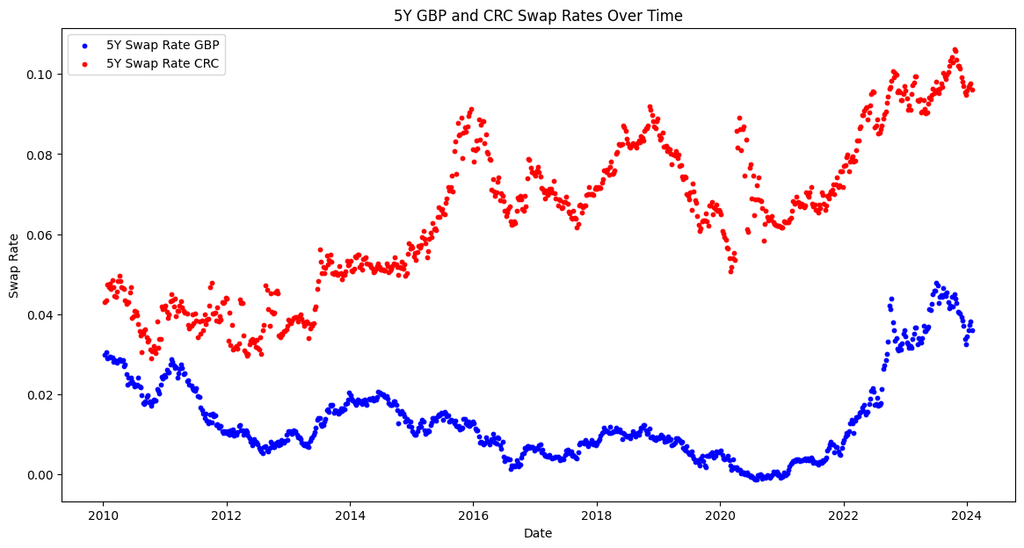

```python
plot_gbps_and_code_s(data, 'CRC')
```

Again, the swap rates above show us that CRC is relatively stable and has a large spread as compared to GBP. Given that these rate are stable and upward trending over time we would expect to make money using CRC for our XCCY strategy. We did in fact make money with it which fits our data, and in fact we made the most money with this pair, indicating the large spread is highly correlated to increase in PNL.

### HUF

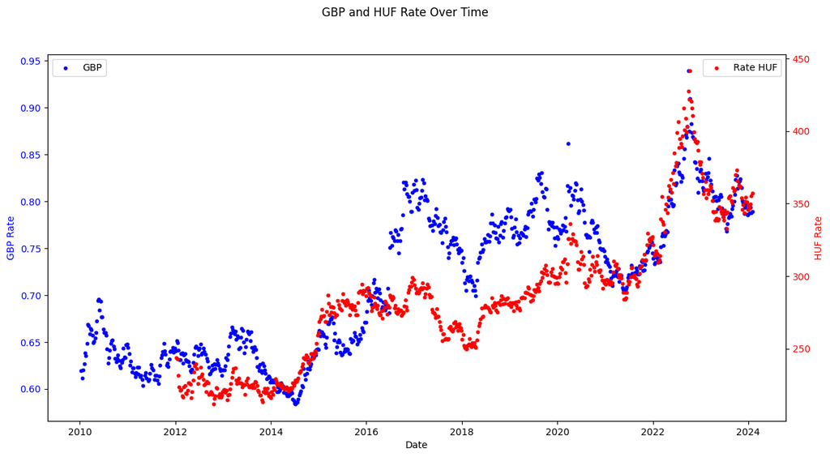

```python
plot_gbp_and_code_rate(data, 'HUF')
```

HUF actually correlates heavily to GBP at least in terms of directionality and the way it moves, particularly through the high interest rate environment post covid. Due to its stability and lack of devaulations, HUF would also seem to be a good candidate for our cross currency strategy.

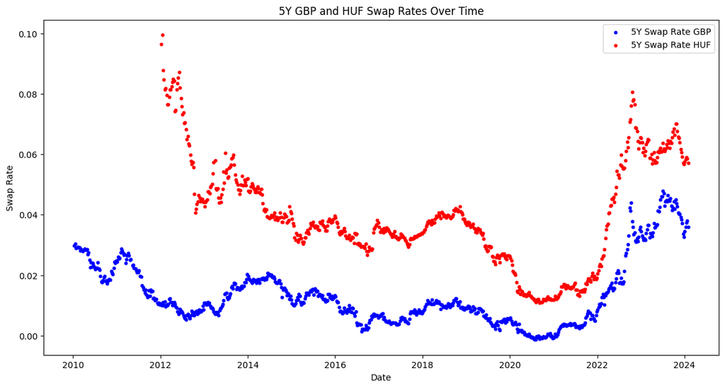

```python
plot_gbps_and_code_s(data, 'HUF')
```

As we can see from the above, 5Y HUF rates also had a nice spread as compared to 5Y GBP rates. Due to this and the exchange rate data above we would expect our strategy to be profitable, which it indeed was. It ended up being our second most profitable strategy, finishing right above RON (although they had very similar profiles and characteristics).

### RON

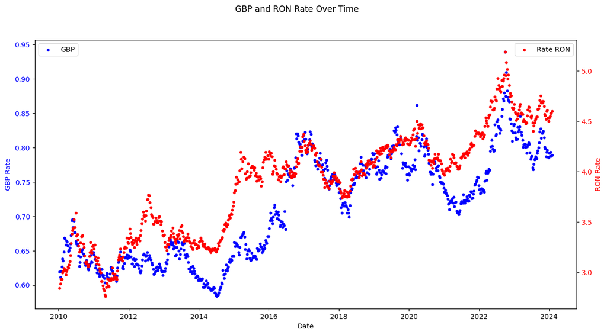

```python
plot_gbp_and_code_rate(data, 'RON')
```

RON behaves with a lot of stability, and due to this it, like HUF above, looks to be a good candidate for our cross currency strategy, trading in a tight band YoY and without a ton of volatility.

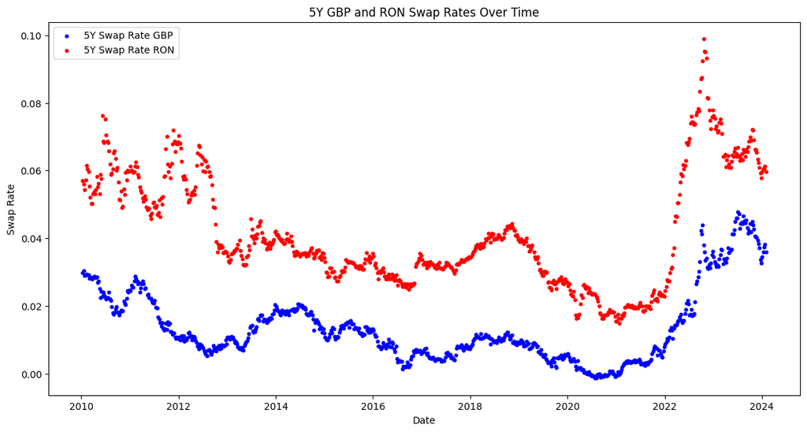

```python
plot_gbps_and_code_s(data, 'RON')
```

As we can see from the above, it maintained a good 5Y spread as compared to GBP, and because of this and its lower volatility, RON was a stable performer throughout our strategy. While it was the worst performer of our profitable strategies (due to what appears to be having the lowest spread over time to 5Y GBP), it was still profitable and would still make sense to trade, particularly for companies looking for exposure to the Romanian market.

# Correlations

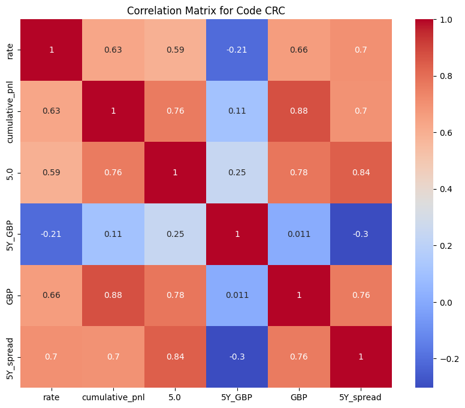

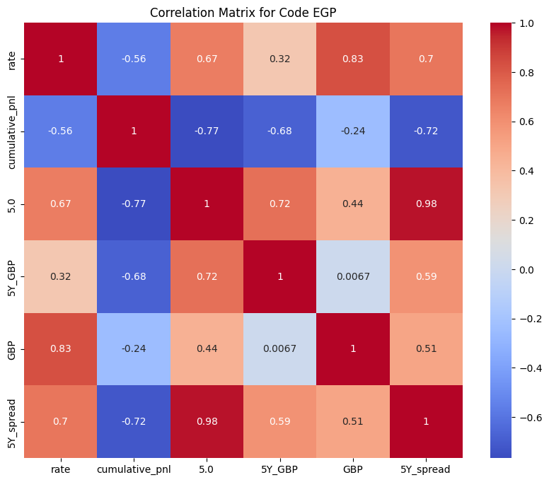

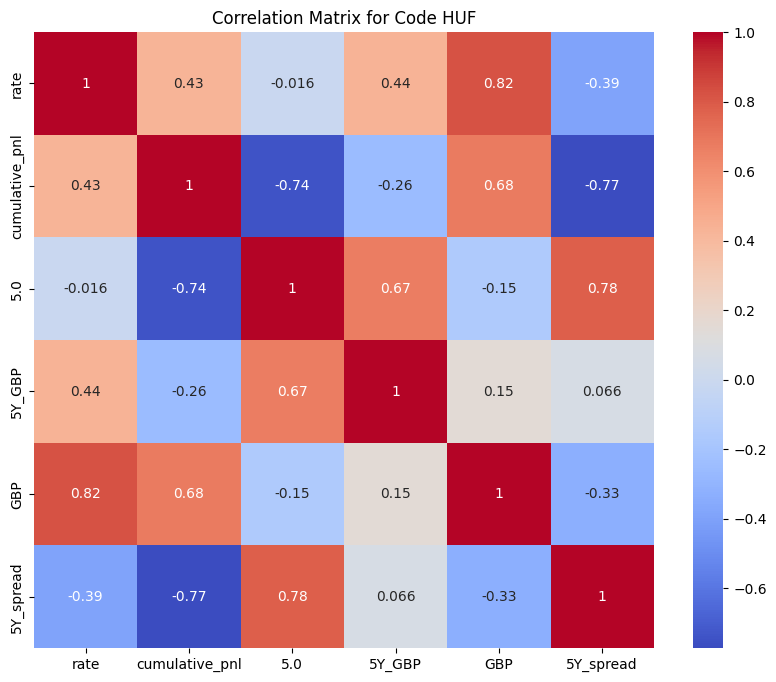

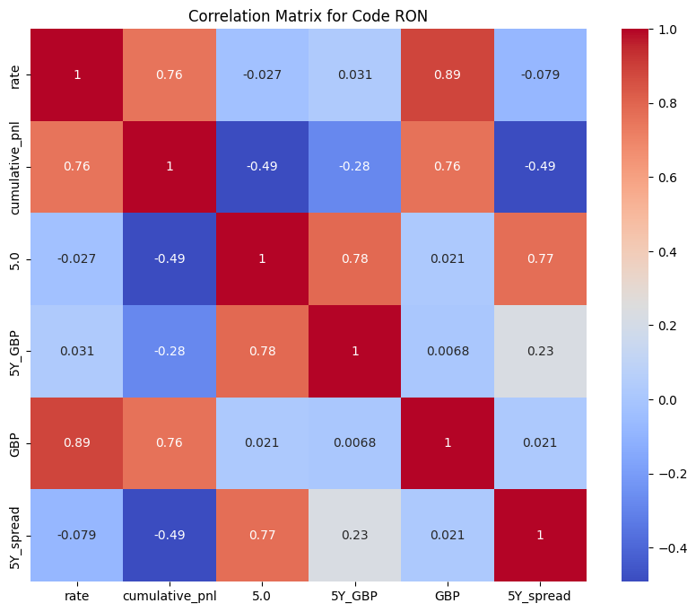

```python
plot_correlation_matrices(data)
```

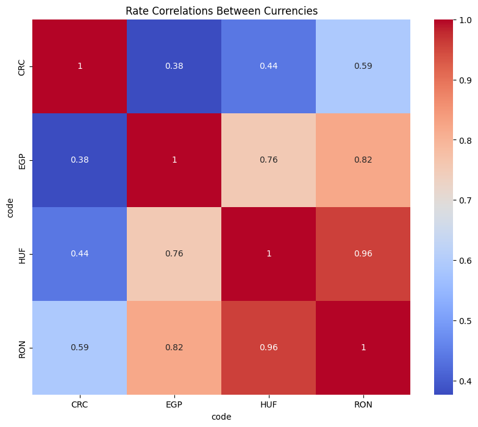

```python
plot_rate_correlations(data)
```

In the above we can see that some of our currencies are highly correlated (especially the euro ones). CRC is the least correlated which makes sense some from a macro and geographic perspective. While HUF and RON are the most, which again makes sense in the same way.

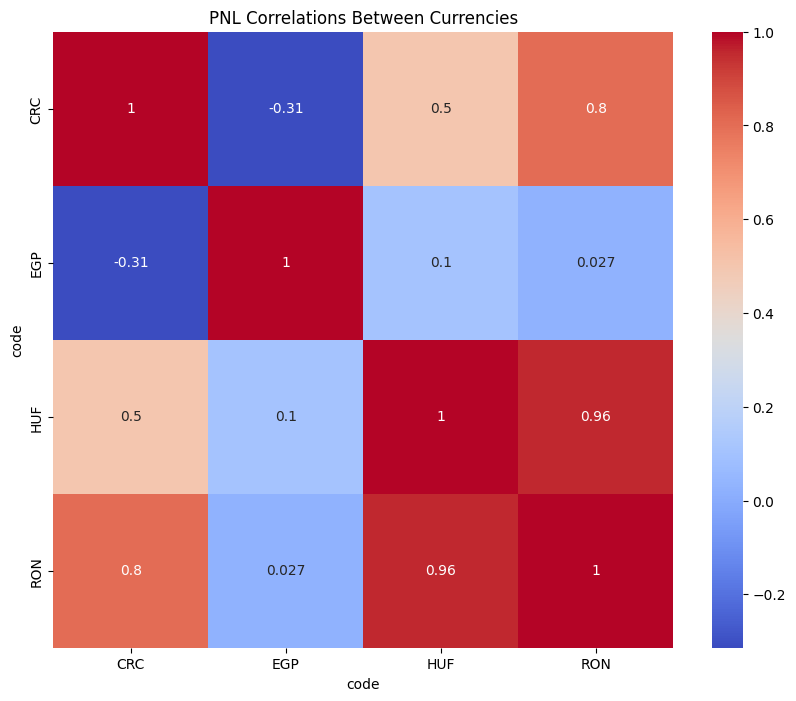

```python
plot_pnl_correlations(data)
```

In the above we can see the PNL correlations between currencies. All the profitable strategies tend to be somewhat correlated, while EGP is not highly correlated to the others (for reasons that we have already mentioned). HUF and RON are again extremely correlated, while CRC is somewhat correlated to both.

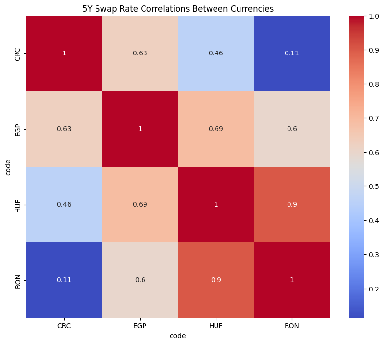

```python
plot_5y_correlations(data)
```

# Summary

Three of our strategies wound up being profitable, while one was not. The main risks here are due to swap rate changes, as well as currency risks. Based on our analysis we were able to determine that the main risk was due to FX risk. While these strategies were profitable, they can be extremely risk as well, as noted by what happened to EGP over the period.